# NYCFlights: Arrival Delay Logictic Model

Michael Raminski

May 1, 2017

## Logsitic and Inverse Logistic Transformation

- Write an R function for the logistic function. The function should accept a `numeric` vector with values `[-Inf,Inf]` and produce a numeric vector in the the range `[0,1]`.

```r
logistic <- function(x){
  return(1 / (1 + exp(-x)))}
```

- Plot the logistic function from `[-10,10]`

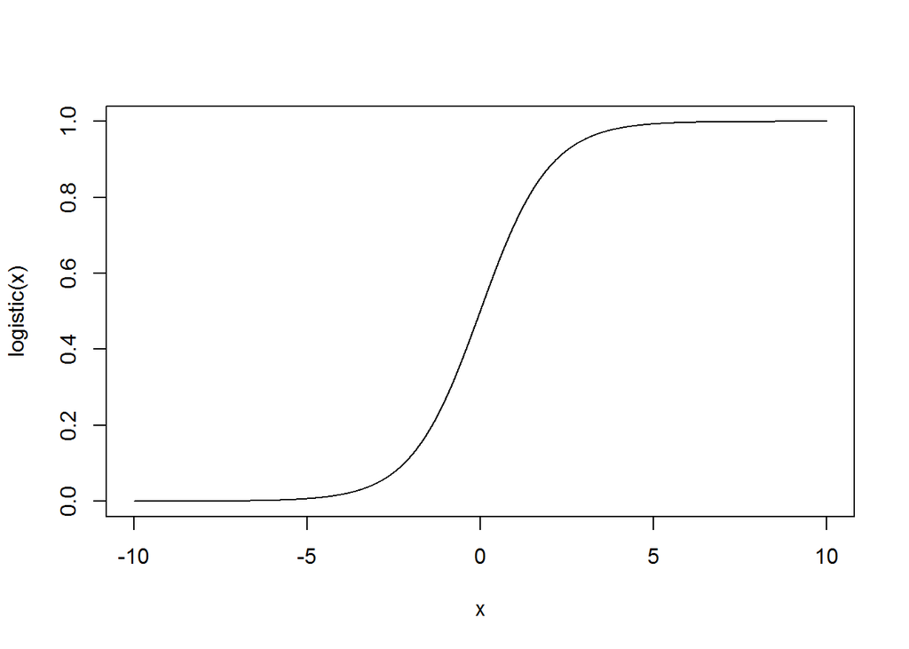

```r
curve(logistic, from = -10, to = 10, n = 10000)
```

- Write a R function for the inverse logistic function. The function should accept a `numeric` vector with values `[0,1]` and prodcuce a numeric vector in the range `[-Inf,Inf]`

```r
logisticInv <- function(y){
  return(log(y/(1-y)))}
```

- Plot the Inverse Logistic function from `[0,1]`

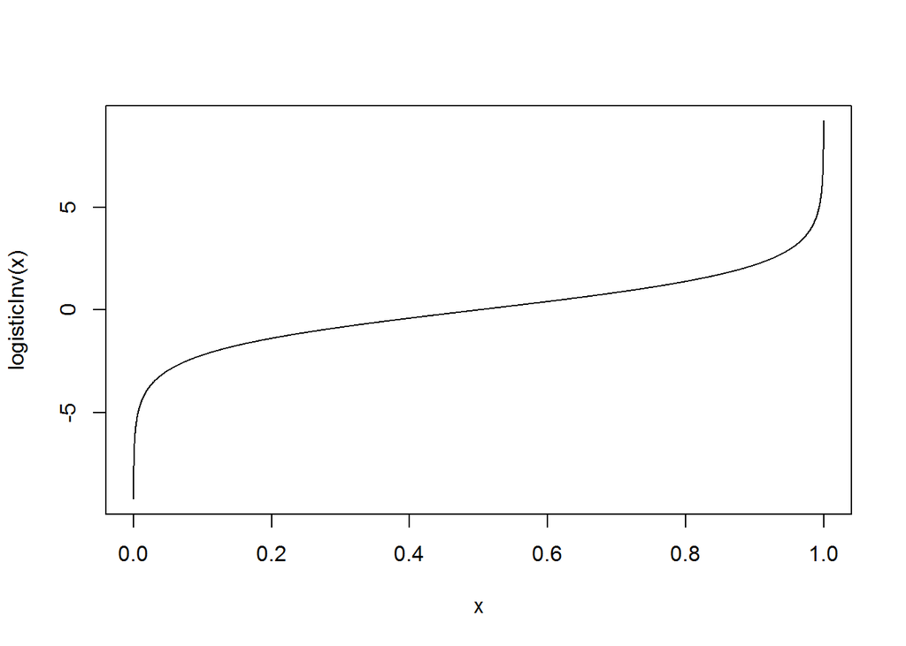

```r
curve(logisticInv, from = 0, to = 1, n = 10000)
```

**Hint:** For plotting curves see `?graphics::curve` or `?ggplot2::stat_function`

# NYCFlights Model

Using the rectangular data that you created from the earlier assignment and following the example from the text and class, create a model for arr_delay >= 22 minutes. Describe/Explain each of the steps and show all work.

#### Step 1: Objective

Use the merged NYC flights dataset to predict the likelihood of a 22 minute or greater delay, using a logistic regression model.

The model will be selected by adding and subtracting parameters until the AIC is minimized. Then, the model performance will be judged by comparing it’s probability of correctly predicting the outcome versus a naive model.

Deliverable: R Markdown files, html knitted file and .Rmd file, uploaded to Git.

#### Step 2: Read in Data and take a sample of 10,000 records as the training dataset

```r
delays <- read.csv("all.csv")
delays <- tbl_df(delays)

delaystrain <- sample_n(delays,10000)
delaystrain
```

```
## # A tibble: 10,000 × 49
##    year.x month   day dep_time sched_dep_time dep_delay arr_time
##     <int> <int> <int>    <int>          <int>     <int>    <int>
## 1    2013     5     4     1433           1429         4     1531
## 2    2013     8    21     1500           1505        -5     1650
## 3    2013     5    31     1105           1110        -5     1335
## 4    2013    11    12     2135           2005        90     2245
## 5    2013    12    20     1252           1259        -7     1520
## 6    2013    11     4      952           1000        -8     1115
## 7    2013     6    10     1239           1200        39     1638
## 8    2013     8     2     1554           1520        34     1706
## 9    2013     3    21     1357           1400        -3     1626
## 10   2013     7     7     1928           1900        28     2238
## # ... with 9,990 more rows, and 42 more variables: sched_arr_time <int>,
## #   arr_delay <int>, carrier <fctr>, flight <int>, tailnum <fctr>,
## #   origin <fctr>, dest <fctr>, air_time <int>, distance <int>,
## #   hour <int>, minute <int>, time_hour.x <fctr>, temp <dbl>, dewp <dbl>,
## #   humid <dbl>, wind_dir <int>, wind_speed <dbl>, wind_gust <dbl>,
## #   precip <dbl>, pressure <dbl>, visib <dbl>, time_hour.y <fctr>,
## #   year.y <int>, type <fctr>, manufacturer <fctr>, model <fctr>,
## #   engines <int>, seats <int>, speed <int>, engine <fctr>, name.x <fctr>,
## #   lat.x <dbl>, lon.x <dbl>, alt.x <int>, tz.x <int>, dst.x <fctr>,
## #   name.y <fctr>, lat.y <dbl>, lon.y <dbl>, alt.y <int>, tz.y <int>,
## #   dst.y <fctr>
```

#### Step 3: Fix Data

##### Add in column delay>=22 = 1, <22 = 0

```r
delaystrain$delay22[delaystrain$arr_delay >= 22] <- 1
delaystrain$delay22[delaystrain$arr_delay < 22] <- 0
```

#### Step 4: Initial Tests

##### Naive Model - Look at probability of 22+ minute delay (Probability ~ 19%)

```r
summarise(delaystrain,
          delay_perc = sum(delay22, na.rm=TRUE) / n())
```

```
## # A tibble: 1 × 1
##   delay_perc
##        <dbl>
## 1      0.186
```

#### Step 5: Exploratory Analysis and Model Fitting

##### Test simple model- only look at departure delay

```r
delaylogistic1 <- glm(formula = delay22 ~ dep_delay, family = binomial, data = delaystrain)
summary(delaylogistic1)
```

```
##
## Call:
## glm(formula = delay22 ~ dep_delay, family = binomial, data = delaystrain)
##
## Deviance Residuals:
##     Min       1Q   Median       3Q      Max
## -2.8112  -0.3251  -0.2661  -0.2069   2.8126
##
## Coefficients:
##              Estimate Std. Error z value Pr(>|z|)
## (Intercept) -2.914164   0.052311  -55.71   <2e-16 ***
## dep_delay    0.102181   0.002444   41.80   <2e-16 ***
## ---
## Signif. codes:  0 '***' 0.001 '**' 0.01 '*' 0.05 '.' 0.1 ' ' 1
##
## (Dispersion parameter for binomial family taken to be 1)
##
##     Null deviance: 9491.6  on 9722  degrees of freedom
## Residual deviance: 4349.4  on 9721  degrees of freedom
##   (277 observations deleted due to missingness)
## AIC: 4353.4
##
## Number of Fisher Scoring iterations: 7
```

##### Include additional variables- add in other variables which were significant in the linear modeling exercise

```r
delaylogistic2 <- glm(formula = delay22 ~ dep_delay + month, family = binomial, data = delaystrain)

delaylogistic3 <- glm(formula = delay22 ~ dep_delay + month + air_time, family = binomial, data = delaystrain)

delaylogistic4 <- glm(formula = delay22 ~ dep_delay + month + air_time + distance, family = binomial, data = delaystrain)

delaylogistic5 <- glm(formula = delay22 ~ dep_delay + month + air_time + distance + dep_time, family = binomial, data = delaystrain)

delaylogistic6 <- glm(formula = delay22 ~ dep_delay + month + air_time + distance + dep_time + humid, family = binomial, data = delaystrain)

delaylogistic7 <- glm(formula = delay22 ~ dep_delay + month + air_time + distance + dep_time + humid + dewp, family = binomial, data = delaystrain)

delaylogistic8 <- glm(formula = delay22 ~ dep_delay + month + air_time + distance + dep_time + humid + dewp + temp, family = binomial, data = delaystrain)

delaylogistic9 <- glm(formula = delay22 ~ dep_delay + month + air_time + distance + dep_time + humid + dewp + temp + pressure, family = binomial, data = delaystrain)

delaylogistic10 <- glm(formula = delay22 ~ dep_delay + month + air_time + distance + dep_time + humid + dewp + temp + pressure + lat.y, family = binomial, data = delaystrain)

delaylogistic11 <- glm(formula = delay22 ~ dep_delay + month + air_time + distance + dep_time + humid + dewp + temp + pressure + lat.y + wind_gust, family = binomial, data = delaystrain)

delaylogistic12 <- glm(formula = delay22 ~ dep_delay + month + air_time + distance + dep_time + humid + dewp + temp + pressure + lat.y + wind_gust + carrier, family = binomial, data = delaystrain)
```

##### Compare models based on the AIC criterion

```r
AIC(delaylogistic2, delaylogistic3, delaylogistic4, delaylogistic5, delaylogistic6, delaylogistic7, delaylogistic8, delaylogistic9, delaylogistic10, delaylogistic11, delaylogistic12)
```

```
##                 df      AIC
## delaylogistic2   3 4355.376
## delaylogistic3   4 4357.331
## delaylogistic4   5 3724.934
## delaylogistic5   6 3716.788
## delaylogistic6   7 3686.717
## delaylogistic7   8 3617.327
## delaylogistic8   9 3617.204
## delaylogistic9  10 3144.584
## delaylogistic10 11 2986.667
## delaylogistic11 12 2987.520
## delaylogistic12 27 2927.976
```

##### AIC minimized at 12 variables and seems to be stabilized- look at summary of 12 variable model

```r
delaylogistic12 <- glm(formula = delay22 ~ dep_delay + month + air_time + distance + dep_time + humid + dewp + temp + pressure + lat.y + wind_gust + carrier, family = binomial, data = delaystrain)
summary(delaylogistic12)
```

```
##
## Call:
## glm(formula = delay22 ~ dep_delay + month + air_time + distance +
##     dep_time + humid + dewp + temp + pressure + lat.y + wind_gust +
##     carrier, family = binomial, data = delaystrain)
##
## Deviance Residuals:
##     Min       1Q   Median       3Q      Max
## -2.4440  -0.2745  -0.1561  -0.0751   3.4793
##
## Coefficients:
##               Estimate Std. Error z value Pr(>|z|)
## (Intercept) -1.681e+01  7.571e+00  -2.220  0.02641 *
## dep_delay    1.239e-01  3.606e-03  34.366  < 2e-16 ***
## month       -1.289e-02  1.481e-02  -0.870  0.38423
## air_time     1.099e-01  4.841e-03  22.696  < 2e-16 ***
## distance    -1.434e-02  6.445e-04 -22.255  < 2e-16 ***
## dep_time     4.160e-04  1.300e-04   3.201  0.00137 **
## humid        2.232e-02  1.373e-02   1.625  0.10408
## dewp        -2.092e-02  2.906e-02  -0.720  0.47150
## temp         4.957e-02  2.732e-02   1.815  0.06959 .
## pressure     8.826e-03  7.184e-03   1.229  0.21921
## lat.y       -4.585e-02  9.747e-03  -4.704 2.55e-06 ***
## wind_gust    2.693e-03  2.042e-03   1.319  0.18719
## carrierAA   -1.357e-01  3.161e-01  -0.429  0.66785
## carrierAS   -1.325e+01  2.601e+02  -0.051  0.95938
## carrierB6    8.629e-01  2.714e-01   3.179  0.00148 **
## carrierDL    3.624e-01  2.869e-01   1.263  0.20649
## carrierEV    6.575e-01  2.636e-01   2.494  0.01262 *
## carrierF9    2.916e+00  6.513e-01   4.476 7.59e-06 ***
## carrierFL    9.941e-01  5.408e-01   1.838  0.06602 .
## carrierHA    3.792e+00  2.760e+00   1.374  0.16947
## carrierMQ    1.427e+00  2.884e-01   4.949 7.44e-07 ***
## carrierOO   -1.076e+01  1.455e+03  -0.007  0.99410
## carrierUA    1.210e-01  2.794e-01   0.433  0.66499
## carrierUS    9.263e-01  3.163e-01   2.928  0.00341 **
## carrierVX   -1.752e-01  6.181e-01  -0.283  0.77686
## carrierWN    1.383e-01  3.457e-01   0.400  0.68918
## carrierYV   -4.253e+00  2.029e+01  -0.210  0.83400
## ---
## Signif. codes:  0 '***' 0.001 '**' 0.01 '*' 0.05 '.' 0.1 ' ' 1
##
## (Dispersion parameter for binomial family taken to be 1)
##
##     Null deviance: 7865.6  on 8449  degrees of freedom
## Residual deviance: 2874.0  on 8423  degrees of freedom
##   (1550 observations deleted due to missingness)
## AIC: 2928
##
## Number of Fisher Scoring iterations: 14
```

##### Remove insignificant variables - remove “dewp” (least significant)

```r
delaylogistic13 <- glm(formula = delay22 ~ dep_delay + month + air_time + distance + dep_time + humid + temp + pressure + lat.y + wind_gust + carrier, family = binomial, data = delaystrain)
summary(delaylogistic13)
```

```
##
## Call:
## glm(formula = delay22 ~ dep_delay + month + air_time + distance +
##     dep_time + humid + temp + pressure + lat.y + wind_gust +
##     carrier, family = binomial, data = delaystrain)
##
## Deviance Residuals:
##     Min       1Q   Median       3Q      Max
## -2.4470  -0.2745  -0.1561  -0.0751   3.4704
##
## Coefficients:
##               Estimate Std. Error z value Pr(>|z|)
## (Intercept) -1.567e+01  7.398e+00  -2.119  0.03413 *
## dep_delay    1.240e-01  3.606e-03  34.372  < 2e-16 ***
## month       -1.362e-02  1.477e-02  -0.922  0.35655
## air_time     1.099e-01  4.839e-03  22.709  < 2e-16 ***
## distance    -1.435e-02  6.443e-04 -22.266  < 2e-16 ***
## dep_time     4.204e-04  1.296e-04   3.243  0.00118 **
## humid        1.269e-02  3.060e-03   4.146 3.38e-05 ***
## temp         3.005e-02  3.319e-03   9.053  < 2e-16 ***
## pressure     8.510e-03  7.165e-03   1.188  0.23494
## lat.y       -4.593e-02  9.749e-03  -4.711 2.47e-06 ***
## wind_gust    2.662e-03  2.050e-03   1.299  0.19404
## carrierAA   -1.359e-01  3.162e-01  -0.430  0.66720
## carrierAS   -1.324e+01  2.602e+02  -0.051  0.95941
## carrierB6    8.606e-01  2.713e-01   3.172  0.00152 **
## carrierDL    3.568e-01  2.867e-01   1.244  0.21334
## carrierEV    6.575e-01  2.635e-01   2.495  0.01258 *
## carrierF9    2.913e+00  6.514e-01   4.472 7.75e-06 ***
## carrierFL    9.917e-01  5.400e-01   1.837  0.06628 .
## carrierHA    3.791e+00  2.779e+00   1.364  0.17252
## carrierMQ    1.425e+00  2.883e-01   4.944 7.64e-07 ***
## carrierOO   -1.068e+01  1.455e+03  -0.007  0.99415
## carrierUA    1.224e-01  2.793e-01   0.438  0.66111
## carrierUS    9.233e-01  3.163e-01   2.919  0.00351 **
## carrierVX   -1.716e-01  6.175e-01  -0.278  0.78104
## carrierWN    1.371e-01  3.456e-01   0.397  0.69158
## carrierYV   -4.237e+00  2.020e+01  -0.210  0.83391
## ---
## Signif. codes:  0 '***' 0.001 '**' 0.01 '*' 0.05 '.' 0.1 ' ' 1
##
## (Dispersion parameter for binomial family taken to be 1)
##
##     Null deviance: 7865.6  on 8449  degrees of freedom
## Residual deviance: 2874.5  on 8424  degrees of freedom
##   (1550 observations deleted due to missingness)
## AIC: 2926.5
##
## Number of Fisher Scoring iterations: 14
```

##### Create a test dataset of 10,000 values

```r
delaystest <- sample_n(delays,10000)
delaystest$delay22[delaystest$arr_delay >= 22] <- 1
delaystest$delay22[delaystest$arr_delay < 22] <- 0
delaystest
```

```
## # A tibble: 10,000 × 50
##    year.x month   day dep_time sched_dep_time dep_delay arr_time
##     <int> <int> <int>    <int>          <int>     <int>    <int>
## 1    2013     7    18     1824           1825        -1     2044
## 2    2013     8    21     1458           1459        -1     1740
## 3    2013     6     9     1824           1734        50     2056
## 4    2013     1    15      625            630        -5      740
## 5    2013     4    24     1627           1535        52     1736
## 6    2013     8     4      645            645         0      933
## 7    2013     7    12     1240           1240         0     1602
## 8    2013     8    18       NA           1115        NA       NA
## 9    2013     2    28     1304           1305        -1     1412
## 10   2013     8    12     1346           1300        46     1602
## # ... with 9,990 more rows, and 43 more variables: sched_arr_time <int>,
## #   arr_delay <int>, carrier <fctr>, flight <int>, tailnum <fctr>,
## #   origin <fctr>, dest <fctr>, air_time <int>, distance <int>,
## #   hour <int>, minute <int>, time_hour.x <fctr>, temp <dbl>, dewp <dbl>,
## #   humid <dbl>, wind_dir <int>, wind_speed <dbl>, wind_gust <dbl>,
## #   precip <dbl>, pressure <dbl>, visib <dbl>, time_hour.y <fctr>,
## #   year.y <int>, type <fctr>, manufacturer <fctr>, model <fctr>,
## #   engines <int>, seats <int>, speed <int>, engine <fctr>, name.x <fctr>,
## #   lat.x <dbl>, lon.x <dbl>, alt.x <int>, tz.x <int>, dst.x <fctr>,
## #   name.y <fctr>, lat.y <dbl>, lon.y <dbl>, alt.y <int>, tz.y <int>,
## #   dst.y <fctr>, delay22 <dbl>
```

##### Apply logistic regression to test dataset

```r
prob <- predict(delaylogistic13, delaystest, type="response")
logit.pred <- factor(prob>.5, levels=c(FALSE,TRUE), labels=c(0,1))
logit.pref <- table(delaystest$delay22, logit.pred, dnn=c("Actual", "Predicted"))
logit.pref
```

```
##       Predicted
## Actual    0    1
##      0 6869  139
##      1  388 1122
```

##### Probability of correctly predicting a non-delay

```r
logit.pref[1,1]/sum(logit.pref[1,])
```

```
## [1] 0.9801655
```

##### Probability of correctly predicting a delay

```r
logit.pref[2,2]/sum(logit.pref[2,])
```

```
## [1] 0.7430464
```

##### Probability of correctly predicting result (overall)

```r
(logit.pref[1,1] + logit.pref[2,2])/sum(logit.pref)
```

```
## [1] 0.938131
```

# Question:

Is this a good model? This is a good model. In comparing the results to a Naive model: -The probability of correctly predicting a “non-delay” is improved from ~81% to ~98% -The probability of correctly predicting a “delay” is improved from ~19% to ~75%

The logistic model has a total probability of predicting the correct outcome of ~94%.

# PART B:

Your model should be good at explaining tardiness. Now, assume that your job is to predict arrival delays a month in advance. You can no longer use all the features in your model. Retrain your model using only features that will be *known* only a month in advance of the departure time. Show all steps as above.

##### Create a new model, based on the previous model but eliminating all variables that aren’t known one month in advance- departure delay and all variables relating to weather

```r
delaylogistic14 <- glm(formula = delay22 ~ month + air_time + distance + dep_time + lat.y + carrier, family = binomial, data = delaystrain)
summary(delaylogistic14)
```

```
##
## Call:
## glm(formula = delay22 ~ month + air_time + distance + dep_time +
##     lat.y + carrier, family = binomial, data = delaystrain)
##
## Deviance Residuals:
##     Min       1Q   Median       3Q      Max
## -1.6854  -0.6832  -0.4636  -0.2848   3.1386
##
## Coefficients:
##               Estimate Std. Error z value Pr(>|z|)
## (Intercept) -3.738e+00  2.651e-01 -14.097  < 2e-16 ***
## month       -3.551e-03  7.859e-03  -0.452 0.651366
## air_time     3.798e-02  2.302e-03  16.497  < 2e-16 ***
## distance    -4.941e-03  3.046e-04 -16.220  < 2e-16 ***
## dep_time     1.584e-03  6.397e-05  24.760  < 2e-16 ***
## lat.y       -1.867e-02  5.358e-03  -3.485 0.000493 ***
## carrierAA   -4.307e-01  1.607e-01  -2.680 0.007367 **
## carrierAS   -1.264e+01  1.843e+02  -0.069 0.945347
## carrierB6    2.025e-01  1.367e-01   1.481 0.138554
## carrierDL   -2.033e-01  1.444e-01  -1.408 0.159225
## carrierEV    4.673e-01  1.312e-01   3.562 0.000368 ***
## carrierF9    1.224e+00  4.879e-01   2.508 0.012129 *
## carrierFL    2.029e-01  3.068e-01   0.661 0.508426
## carrierHA    1.079e+00  1.204e+00   0.896 0.370170
## carrierMQ    3.681e-01  1.471e-01   2.503 0.012310 *
## carrierOO   -1.336e+01  8.827e+02  -0.015 0.987927
## carrierUA   -8.150e-02  1.427e-01  -0.571 0.567842
## carrierUS   -1.205e-01  1.672e-01  -0.721 0.471203
## carrierVX   -6.707e-01  3.410e-01  -1.967 0.049219 *
## carrierWN    1.115e-01  1.882e-01   0.592 0.553702
## carrierYV    8.671e-02  6.866e-01   0.126 0.899506
## ---
## Signif. codes:  0 '***' 0.001 '**' 0.01 '*' 0.05 '.' 0.1 ' ' 1
##
## (Dispersion parameter for binomial family taken to be 1)
##
##     Null deviance: 9301.6  on 9519  degrees of freedom
## Residual deviance: 8203.5  on 9499  degrees of freedom
##   (480 observations deleted due to missingness)
## AIC: 8245.5
##
## Number of Fisher Scoring iterations: 13
```

##### Apply logistic regression to test dataset

```r
prob2 <- predict(delaylogistic14, delaystest, type="response")
logit.pred2 <- factor(prob2>.5, levels=c(FALSE,TRUE), labels=c(0,1))
logit.pref2 <- table(delaystest$delay22, logit.pred2, dnn=c("Actual", "Predicted"))
logit.pref2
```

```
##       Predicted
## Actual    0    1
##      0 7578  112
##      1 1642  205
```

##### Probability of correctly predicting a non-delay

```r
logit.pref2[1,1]/sum(logit.pref2[1,])
```

```
## [1] 0.9854356
```

##### Probability of correctly predicting a delay

```r
logit.pref2[2,2]/sum(logit.pref2[2,])
```

```
## [1] 0.1109908
```

##### Probability of correctly predicting result (overall)

```r
(logit.pref2[1,1] + logit.pref2[2,2])/sum(logit.pref2)
```

```
## [1] 0.8160847
```

# Question:

Is this a good model? This is not a good model. In comparing the results to the original model: -The AIC has increased significantly -The probability of correctly predicting a “non-delay” is relatively unchanged (~98%) -The probability of correctly predicting a “delay” is decreased from ~75% to ~10%

The logistic model now has a total probability of predicting the correct outcome of ~81%, and our probability of predicting a delay is actually lower than in the naive model.